# Risk Factor Analysis

## Outcome Variable

**Outcome Variable:** ever_co

## Predictor Variables

**Intervention Variable:** fage

**Adjustment Set:**

- arm
- W_mage
- meducyrs
- feducyrs
- W_mhtcm
- W_mwtkg
- W_mbmi
- W_fhtcm
- single
- brthmon
- delta_W_mage
- delta_meducyrs
- delta_feducyrs
- delta_W_mhtcm
- delta_W_mwtkg
- delta_W_mbmi
- delta_W_fhtcm
- delta_single
- delta_brthmon

## Stratifying Variables

The analysis was stratified on these variable(s):

- agecat
- studyid
- country

## Data Summary

| agecat | studyid | country | fage | ever_co | n_cell | n |
| --- | --- | --- | --- | --- | --- | --- |
| 0-24 months | ki0047075b-MAL-ED | BANGLADESH | >=38 | 0 | 61 | 151 |
| 0-24 months | ki0047075b-MAL-ED | BANGLADESH | >=38 | 1 | 8 | 151 |
| 0-24 months | ki0047075b-MAL-ED | BANGLADESH | <32 | 0 | 22 | 151 |
| 0-24 months | ki0047075b-MAL-ED | BANGLADESH | <32 | 1 | 8 | 151 |
| 0-24 months | ki0047075b-MAL-ED | BANGLADESH | [32-38) | 0 | 45 | 151 |
| 0-24 months | ki0047075b-MAL-ED | BANGLADESH | [32-38) | 1 | 7 | 151 |
| 0-24 months | ki0047075b-MAL-ED | BRAZIL | >=38 | 0 | 30 | 79 |
| 0-24 months | ki0047075b-MAL-ED | BRAZIL | >=38 | 1 | 0 | 79 |
| 0-24 months | ki0047075b-MAL-ED | BRAZIL | <32 | 0 | 18 | 79 |
| 0-24 months | ki0047075b-MAL-ED | BRAZIL | <32 | 1 | 0 | 79 |
| 0-24 months | ki0047075b-MAL-ED | BRAZIL | [32-38) | 0 | 31 | 79 |
| 0-24 months | ki0047075b-MAL-ED | BRAZIL | [32-38) | 1 | 0 | 79 |
| 0-24 months | ki0047075b-MAL-ED | INDIA | >=38 | 0 | 33 | 161 |
| 0-24 months | ki0047075b-MAL-ED | INDIA | >=38 | 1 | 3 | 161 |
| 0-24 months | ki0047075b-MAL-ED | INDIA | <32 | 0 | 36 | 161 |
| 0-24 months | ki0047075b-MAL-ED | INDIA | <32 | 1 | 17 | 161 |
| 0-24 months | ki0047075b-MAL-ED | INDIA | [32-38) | 0 | 56 | 161 |
| 0-24 months | ki0047075b-MAL-ED | INDIA | [32-38) | 1 | 16 | 161 |
| 0-24 months | ki0047075b-MAL-ED | NEPAL | >=38 | 0 | 14 | 79 |
| 0-24 months | ki0047075b-MAL-ED | NEPAL | >=38 | 1 | 3 | 79 |
| 0-24 months | ki0047075b-MAL-ED | NEPAL | <32 | 0 | 13 | 79 |
| 0-24 months | ki0047075b-MAL-ED | NEPAL | <32 | 1 | 2 | 79 |
| 0-24 months | ki0047075b-MAL-ED | NEPAL | [32-38) | 0 | 43 | 79 |
| 0-24 months | ki0047075b-MAL-ED | NEPAL | [32-38) | 1 | 4 | 79 |
| 0-24 months | ki0047075b-MAL-ED | PERU | >=38 | 0 | 27 | 85 |
| 0-24 months | ki0047075b-MAL-ED | PERU | >=38 | 1 | 0 | 85 |
| 0-24 months | ki0047075b-MAL-ED | PERU | <32 | 0 | 27 | 85 |
| 0-24 months | ki0047075b-MAL-ED | PERU | <32 | 1 | 2 | 85 |
| 0-24 months | ki0047075b-MAL-ED | PERU | [32-38) | 0 | 27 | 85 |
| 0-24 months | ki0047075b-MAL-ED | PERU | [32-38) | 1 | 2 | 85 |

[output cut: 204 more lines]

The following strata were considered:

- agecat: 0-24 months, studyid: ki0047075b-MAL-ED, country: BANGLADESH
- agecat: 0-24 months, studyid: ki0047075b-MAL-ED, country: BRAZIL
- agecat: 0-24 months, studyid: ki0047075b-MAL-ED, country: INDIA
- agecat: 0-24 months, studyid: ki0047075b-MAL-ED, country: NEPAL
- agecat: 0-24 months, studyid: ki0047075b-MAL-ED, country: PERU
- agecat: 0-24 months, studyid: ki0047075b-MAL-ED, country: SOUTH AFRICA
- agecat: 0-24 months, studyid: ki0047075b-MAL-ED, country: TANZANIA, UNITED REPUBLIC OF
- agecat: 0-24 months, studyid: ki1000304b-SAS-CompFeed, country: INDIA
- agecat: 0-24 months, studyid: ki1000304b-SAS-FoodSuppl, country: INDIA
- agecat: 0-24 months, studyid: ki1119695-PROBIT, country: BELARUS
- agecat: 0-24 months, studyid: ki1135781-COHORTS, country: GUATEMALA
- agecat: 0-24 months, studyid: ki1135781-COHORTS, country: PHILIPPINES
- agecat: 0-24 months, studyid: ki1148112-LCNI-5, country: MALAWI
- agecat: 0-6 months, studyid: ki0047075b-MAL-ED, country: BANGLADESH
- agecat: 0-6 months, studyid: ki0047075b-MAL-ED, country: BRAZIL
- agecat: 0-6 months, studyid: ki0047075b-MAL-ED, country: INDIA
- agecat: 0-6 months, studyid: ki0047075b-MAL-ED, country: NEPAL
- agecat: 0-6 months, studyid: ki0047075b-MAL-ED, country: PERU
- agecat: 0-6 months, studyid: ki0047075b-MAL-ED, country: SOUTH AFRICA
- agecat: 0-6 months, studyid: ki0047075b-MAL-ED, country: TANZANIA, UNITED REPUBLIC OF
- agecat: 0-6 months, studyid: ki1000304b-SAS-CompFeed, country: INDIA
- agecat: 0-6 months, studyid: ki1000304b-SAS-FoodSuppl, country: INDIA
- agecat: 0-6 months, studyid: ki1119695-PROBIT, country: BELARUS
- agecat: 0-6 months, studyid: ki1135781-COHORTS, country: GUATEMALA
- agecat: 0-6 months, studyid: ki1135781-COHORTS, country: PHILIPPINES
- agecat: 0-6 months, studyid: ki1148112-LCNI-5, country: MALAWI
- agecat: 6-24 months, studyid: ki0047075b-MAL-ED, country: BANGLADESH
- agecat: 6-24 months, studyid: ki0047075b-MAL-ED, country: BRAZIL
- agecat: 6-24 months, studyid: ki0047075b-MAL-ED, country: INDIA
- agecat: 6-24 months, studyid: ki0047075b-MAL-ED, country: NEPAL
- agecat: 6-24 months, studyid: ki0047075b-MAL-ED, country: PERU
- agecat: 6-24 months, studyid: ki0047075b-MAL-ED, country: SOUTH AFRICA
- agecat: 6-24 months, studyid: ki0047075b-MAL-ED, country: TANZANIA, UNITED REPUBLIC OF
- agecat: 6-24 months, studyid: ki1000304b-SAS-CompFeed, country: INDIA
- agecat: 6-24 months, studyid: ki1000304b-SAS-FoodSuppl, country: INDIA
- agecat: 6-24 months, studyid: ki1119695-PROBIT, country: BELARUS
- agecat: 6-24 months, studyid: ki1135781-COHORTS, country: GUATEMALA
- agecat: 6-24 months, studyid: ki1135781-COHORTS, country: PHILIPPINES
- agecat: 6-24 months, studyid: ki1148112-LCNI-5, country: MALAWI

### Dropped Strata

Some strata were dropped due to rare outcomes:

- agecat: 0-24 months, studyid: ki0047075b-MAL-ED, country: BRAZIL
- agecat: 0-24 months, studyid: ki0047075b-MAL-ED, country: INDIA
- agecat: 0-24 months, studyid: ki0047075b-MAL-ED, country: NEPAL
- agecat: 0-24 months, studyid: ki0047075b-MAL-ED, country: PERU
- agecat: 0-24 months, studyid: ki0047075b-MAL-ED, country: SOUTH AFRICA
- agecat: 0-24 months, studyid: ki0047075b-MAL-ED, country: TANZANIA, UNITED REPUBLIC OF
- agecat: 0-24 months, studyid: ki1119695-PROBIT, country: BELARUS
- agecat: 0-24 months, studyid: ki1148112-LCNI-5, country: MALAWI
- agecat: 0-6 months, studyid: ki0047075b-MAL-ED, country: BANGLADESH
- agecat: 0-6 months, studyid: ki0047075b-MAL-ED, country: BRAZIL
- agecat: 0-6 months, studyid: ki0047075b-MAL-ED, country: INDIA
- agecat: 0-6 months, studyid: ki0047075b-MAL-ED, country: NEPAL
- agecat: 0-6 months, studyid: ki0047075b-MAL-ED, country: PERU
- agecat: 0-6 months, studyid: ki0047075b-MAL-ED, country: SOUTH AFRICA
- agecat: 0-6 months, studyid: ki0047075b-MAL-ED, country: TANZANIA, UNITED REPUBLIC OF
- agecat: 0-6 months, studyid: ki1000304b-SAS-FoodSuppl, country: INDIA
- agecat: 0-6 months, studyid: ki1119695-PROBIT, country: BELARUS
- agecat: 0-6 months, studyid: ki1135781-COHORTS, country: GUATEMALA
- agecat: 0-6 months, studyid: ki1148112-LCNI-5, country: MALAWI
- agecat: 6-24 months, studyid: ki0047075b-MAL-ED, country: BRAZIL
- agecat: 6-24 months, studyid: ki0047075b-MAL-ED, country: INDIA
- agecat: 6-24 months, studyid: ki0047075b-MAL-ED, country: NEPAL
- agecat: 6-24 months, studyid: ki0047075b-MAL-ED, country: PERU
- agecat: 6-24 months, studyid: ki0047075b-MAL-ED, country: SOUTH AFRICA
- agecat: 6-24 months, studyid: ki0047075b-MAL-ED, country: TANZANIA, UNITED REPUBLIC OF
- agecat: 6-24 months, studyid: ki1119695-PROBIT, country: BELARUS
- agecat: 6-24 months, studyid: ki1148112-LCNI-5, country: MALAWI

## Methods Detail

We’re interested in the causal parameters $E[Y_a]$ for all values of $a \in \mathcal{A}$. These parameters represent the mean outcome if, possibly contrary to fact, we intervened to set all units to have $A=a$. Under the randomization and positivity assumptions, these are identified by the statistical parameters $\psi_a=E_W[E_{Y|A,W}(Y|A=a,W)]$. In addition, we’re interested in the mean of $Y$, $E[Y]$ under no intervention (the observed mean). We will estimate these parameters by using SuperLearner to fit the relevant likelihood factors – $E_{Y|A,W}(Y|A=a,W)$ and $p(A=a|W)$, and then updating our likelihood fit using a joint TMLE.

For unadjusted analyses ($W=\{\}$), initial likelihoods were estimated using Lrnr_glm to estimate the simple $E(Y|A)$ and Lrnr_mean to estimate $p(A)$. For adjusted analyses, a small library containing Lrnr_glmnet, Lrnr_xgboost, and Lrnr_mean was used.

Having estimated these parameters, we will then use the delta method to estimate relative risks and attributable risks relative to a prespecified baseline level of $A$.

# Results Detail

## Results Plots

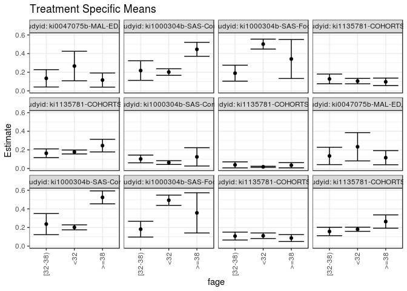

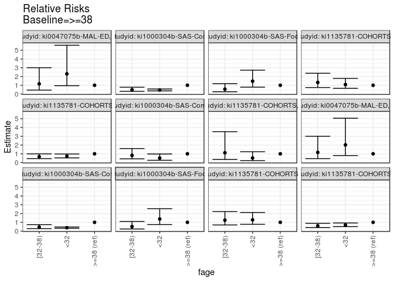

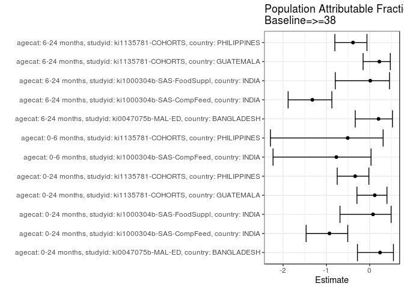

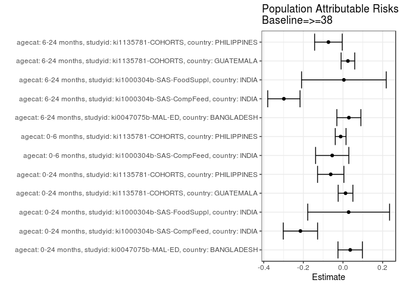

## Results Table

### Parameter: TSM

| agecat | studyid | country | intervention_level | baseline_level | estimate | ci_lower | ci_upper |
| --- | --- | --- | --- | --- | --- | --- | --- |
| 0-24 months | ki0047075b-MAL-ED | BANGLADESH | >=38 | NA | 0.1159420 | 0.0401494 | 0.1917347 |
| 0-24 months | ki0047075b-MAL-ED | BANGLADESH | <32 | NA | 0.2666667 | 0.1078978 | 0.4254355 |
| 0-24 months | ki0047075b-MAL-ED | BANGLADESH | [32-38) | NA | 0.1346154 | 0.0415386 | 0.2276921 |
| 0-24 months | ki1000304b-SAS-CompFeed | INDIA | >=38 | NA | 0.4457778 | 0.3707148 | 0.5208408 |
| 0-24 months | ki1000304b-SAS-CompFeed | INDIA | <32 | NA | 0.2020978 | 0.1669711 | 0.2372246 |
| 0-24 months | ki1000304b-SAS-CompFeed | INDIA | [32-38) | NA | 0.2179046 | 0.1125994 | 0.3232099 |
| 0-24 months | ki1000304b-SAS-FoodSuppl | INDIA | >=38 | NA | 0.3422805 | 0.1331957 | 0.5513653 |
| 0-24 months | ki1000304b-SAS-FoodSuppl | INDIA | <32 | NA | 0.5021451 | 0.4487955 | 0.5554948 |
| 0-24 months | ki1000304b-SAS-FoodSuppl | INDIA | [32-38) | NA | 0.1898633 | 0.1041573 | 0.2755694 |
| 0-24 months | ki1135781-COHORTS | GUATEMALA | >=38 | NA | 0.0968735 | 0.0565304 | 0.1372167 |
| 0-24 months | ki1135781-COHORTS | GUATEMALA | <32 | NA | 0.1047046 | 0.0756574 | 0.1337518 |
| 0-24 months | ki1135781-COHORTS | GUATEMALA | [32-38) | NA | 0.1282068 | 0.0760542 | 0.1803595 |
| 0-24 months | ki1135781-COHORTS | PHILIPPINES | >=38 | NA | 0.2459033 | 0.1778942 | 0.3139125 |
| 0-24 months | ki1135781-COHORTS | PHILIPPINES | <32 | NA | 0.1772011 | 0.1561668 | 0.1982354 |
| 0-24 months | ki1135781-COHORTS | PHILIPPINES | [32-38) | NA | 0.1637139 | 0.1166520 | 0.2107758 |
| 0-6 months | ki1000304b-SAS-CompFeed | INDIA | >=38 | NA | 0.1250000 | 0.0265956 | 0.2234044 |
| 0-6 months | ki1000304b-SAS-CompFeed | INDIA | <32 | NA | 0.0635930 | 0.0431567 | 0.0840293 |
| 0-6 months | ki1000304b-SAS-CompFeed | INDIA | [32-38) | NA | 0.1025641 | 0.0610899 | 0.1440383 |
| 0-6 months | ki1135781-COHORTS | PHILIPPINES | >=38 | NA | 0.0348875 | 0.0069805 | 0.0627945 |
| 0-6 months | ki1135781-COHORTS | PHILIPPINES | <32 | NA | 0.0180459 | 0.0119448 | 0.0241470 |
| 0-6 months | ki1135781-COHORTS | PHILIPPINES | [32-38) | NA | 0.0388845 | 0.0066466 | 0.0711225 |
| 6-24 months | ki0047075b-MAL-ED | BANGLADESH | >=38 | NA | 0.1159420 | 0.0401494 | 0.1917347 |
| 6-24 months | ki0047075b-MAL-ED | BANGLADESH | <32 | NA | 0.2333333 | 0.0814808 | 0.3851858 |
| 6-24 months | ki0047075b-MAL-ED | BANGLADESH | [32-38) | NA | 0.1346154 | 0.0415386 | 0.2276921 |
| 6-24 months | ki1000304b-SAS-CompFeed | INDIA | >=38 | NA | 0.5232982 | 0.4538303 | 0.5927660 |
| 6-24 months | ki1000304b-SAS-CompFeed | INDIA | <32 | NA | 0.2017380 | 0.1750242 | 0.2284517 |
| 6-24 months | ki1000304b-SAS-CompFeed | INDIA | [32-38) | NA | 0.2366521 | 0.1233335 | 0.3499708 |
| 6-24 months | ki1000304b-SAS-FoodSuppl | INDIA | >=38 | NA | 0.3569945 | 0.1411316 | 0.5728574 |
| 6-24 months | ki1000304b-SAS-FoodSuppl | INDIA | <32 | NA | 0.4925967 | 0.4374963 | 0.5476971 |
| 6-24 months | ki1000304b-SAS-FoodSuppl | INDIA | [32-38) | NA | 0.1818498 | 0.0972940 | 0.2664057 |
| 6-24 months | ki1135781-COHORTS | GUATEMALA | >=38 | NA | 0.0868172 | 0.0495458 | 0.1240886 |
| 6-24 months | ki1135781-COHORTS | GUATEMALA | <32 | NA | 0.1111611 | 0.0812758 | 0.1410464 |
| 6-24 months | ki1135781-COHORTS | GUATEMALA | [32-38) | NA | 0.1079583 | 0.0656094 | 0.1503072 |
| 6-24 months | ki1135781-COHORTS | PHILIPPINES | >=38 | NA | 0.2639386 | 0.1926233 | 0.3352539 |
| 6-24 months | ki1135781-COHORTS | PHILIPPINES | <32 | NA | 0.1812264 | 0.1588311 | 0.2036216 |
| 6-24 months | ki1135781-COHORTS | PHILIPPINES | [32-38) | NA | 0.1571669 | 0.1121838 | 0.2021501 |

### Parameter: E(Y)

| agecat | studyid | country | intervention_level | baseline_level | estimate | ci_lower | ci_upper |
| --- | --- | --- | --- | --- | --- | --- | --- |
| 0-24 months | ki0047075b-MAL-ED | BANGLADESH | NA | NA | 0.1523179 | 0.0948144 | 0.2098214 |
| 0-24 months | ki1000304b-SAS-CompFeed | INDIA | NA | NA | 0.2311258 | 0.1911027 | 0.2711489 |
| 0-24 months | ki1000304b-SAS-FoodSuppl | INDIA | NA | NA | 0.3708134 | 0.3244530 | 0.4171738 |
| 0-24 months | ki1135781-COHORTS | GUATEMALA | NA | NA | 0.1097276 | 0.0926320 | 0.1268233 |
| 0-24 months | ki1135781-COHORTS | PHILIPPINES | NA | NA | 0.1840762 | 0.1700627 | 0.1980897 |
| 0-6 months | ki1000304b-SAS-CompFeed | INDIA | NA | NA | 0.0706196 | 0.0480792 | 0.0931600 |
| 0-6 months | ki1135781-COHORTS | PHILIPPINES | NA | NA | 0.0231450 | 0.0177070 | 0.0285830 |
| 6-24 months | ki0047075b-MAL-ED | BANGLADESH | NA | NA | 0.1456954 | 0.0892366 | 0.2021542 |
| 6-24 months | ki1000304b-SAS-CompFeed | INDIA | NA | NA | 0.2251082 | 0.1905625 | 0.2596539 |
| 6-24 months | ki1000304b-SAS-FoodSuppl | INDIA | NA | NA | 0.3615960 | 0.3145115 | 0.4086805 |
| 6-24 months | ki1135781-COHORTS | GUATEMALA | NA | NA | 0.1116838 | 0.0935814 | 0.1297863 |
| 6-24 months | ki1135781-COHORTS | PHILIPPINES | NA | NA | 0.1905112 | 0.1757477 | 0.2052747 |

### Parameter: RR

| agecat | studyid | country | intervention_level | baseline_level | estimate | ci_lower | ci_upper |
| --- | --- | --- | --- | --- | --- | --- | --- |
| 0-24 months | ki0047075b-MAL-ED | BANGLADESH | >=38 | >=38 | 1.0000000 | 1.0000000 | 1.0000000 |
| 0-24 months | ki0047075b-MAL-ED | BANGLADESH | <32 | >=38 | 2.3000000 | 0.9499965 | 5.5684414 |
| 0-24 months | ki0047075b-MAL-ED | BANGLADESH | [32-38) | >=38 | 1.1610577 | 0.4483418 | 3.0067571 |
| 0-24 months | ki1000304b-SAS-CompFeed | INDIA | >=38 | >=38 | 1.0000000 | 1.0000000 | 1.0000000 |
| 0-24 months | ki1000304b-SAS-CompFeed | INDIA | <32 | >=38 | 0.4533600 | 0.3572698 | 0.5752943 |
| 0-24 months | ki1000304b-SAS-CompFeed | INDIA | [32-38) | >=38 | 0.4888189 | 0.3072718 | 0.7776303 |
| 0-24 months | ki1000304b-SAS-FoodSuppl | INDIA | >=38 | >=38 | 1.0000000 | 1.0000000 | 1.0000000 |
| 0-24 months | ki1000304b-SAS-FoodSuppl | INDIA | <32 | >=38 | 1.4670574 | 0.7892664 | 2.7269088 |
| 0-24 months | ki1000304b-SAS-FoodSuppl | INDIA | [32-38) | >=38 | 0.5547010 | 0.2594262 | 1.1860531 |
| 0-24 months | ki1135781-COHORTS | GUATEMALA | >=38 | >=38 | 1.0000000 | 1.0000000 | 1.0000000 |
| 0-24 months | ki1135781-COHORTS | GUATEMALA | <32 | >=38 | 1.0808377 | 0.6561083 | 1.7805142 |
| 0-24 months | ki1135781-COHORTS | GUATEMALA | [32-38) | >=38 | 1.3234452 | 0.7395352 | 2.3683892 |
| 0-24 months | ki1135781-COHORTS | PHILIPPINES | >=38 | >=38 | 1.0000000 | 1.0000000 | 1.0000000 |
| 0-24 months | ki1135781-COHORTS | PHILIPPINES | <32 | >=38 | 0.7206129 | 0.5334427 | 0.9734558 |
| 0-24 months | ki1135781-COHORTS | PHILIPPINES | [32-38) | >=38 | 0.6657651 | 0.4467553 | 0.9921386 |
| 0-6 months | ki1000304b-SAS-CompFeed | INDIA | >=38 | >=38 | 1.0000000 | 1.0000000 | 1.0000000 |
| 0-6 months | ki1000304b-SAS-CompFeed | INDIA | <32 | >=38 | 0.5087440 | 0.2651710 | 0.9760514 |
| 0-6 months | ki1000304b-SAS-CompFeed | INDIA | [32-38) | >=38 | 0.8205128 | 0.4199560 | 1.6031234 |
| 0-6 months | ki1135781-COHORTS | PHILIPPINES | >=38 | >=38 | 1.0000000 | 1.0000000 | 1.0000000 |
| 0-6 months | ki1135781-COHORTS | PHILIPPINES | <32 | >=38 | 0.5172596 | 0.2170346 | 1.2327870 |
| 0-6 months | ki1135781-COHORTS | PHILIPPINES | [32-38) | >=38 | 1.1145695 | 0.3521405 | 3.5277539 |
| 6-24 months | ki0047075b-MAL-ED | BANGLADESH | >=38 | >=38 | 1.0000000 | 1.0000000 | 1.0000000 |
| 6-24 months | ki0047075b-MAL-ED | BANGLADESH | <32 | >=38 | 2.0125000 | 0.8000739 | 5.0622279 |
| 6-24 months | ki0047075b-MAL-ED | BANGLADESH | [32-38) | >=38 | 1.1610577 | 0.4483418 | 3.0067571 |
| 6-24 months | ki1000304b-SAS-CompFeed | INDIA | >=38 | >=38 | 1.0000000 | 1.0000000 | 1.0000000 |
| 6-24 months | ki1000304b-SAS-CompFeed | INDIA | <32 | >=38 | 0.3855125 | 0.3173584 | 0.4683029 |
| 6-24 months | ki1000304b-SAS-CompFeed | INDIA | [32-38) | >=38 | 0.4522319 | 0.2782614 | 0.7349699 |
| 6-24 months | ki1000304b-SAS-FoodSuppl | INDIA | >=38 | >=38 | 1.0000000 | 1.0000000 | 1.0000000 |
| 6-24 months | ki1000304b-SAS-FoodSuppl | INDIA | <32 | >=38 | 1.3798440 | 0.7450373 | 2.5555359 |
| 6-24 months | ki1000304b-SAS-FoodSuppl | INDIA | [32-38) | >=38 | 0.5093911 | 0.2373459 | 1.0932539 |
| 6-24 months | ki1135781-COHORTS | GUATEMALA | >=38 | >=38 | 1.0000000 | 1.0000000 | 1.0000000 |
| 6-24 months | ki1135781-COHORTS | GUATEMALA | <32 | >=38 | 1.2804043 | 0.7720973 | 2.1233530 |
| 6-24 months | ki1135781-COHORTS | GUATEMALA | [32-38) | >=38 | 1.2435125 | 0.6951018 | 2.2245999 |
| 6-24 months | ki1135781-COHORTS | PHILIPPINES | >=38 | >=38 | 1.0000000 | 1.0000000 | 1.0000000 |
| 6-24 months | ki1135781-COHORTS | PHILIPPINES | <32 | >=38 | 0.6866232 | 0.5102064 | 0.9240406 |
| 6-24 months | ki1135781-COHORTS | PHILIPPINES | [32-38) | >=38 | 0.5954678 | 0.4016811 | 0.8827447 |

### Parameter: PAR

| agecat | studyid | country | intervention_level | baseline_level | estimate | ci_lower | ci_upper |
| --- | --- | --- | --- | --- | --- | --- | --- |
| 0-24 months | ki0047075b-MAL-ED | BANGLADESH | >=38 | NA | 0.0363759 | -0.0252782 | 0.0980299 |
| 0-24 months | ki1000304b-SAS-CompFeed | INDIA | >=38 | NA | -0.2146520 | -0.3012396 | -0.1280644 |
| 0-24 months | ki1000304b-SAS-FoodSuppl | INDIA | >=38 | NA | 0.0285329 | -0.1778856 | 0.2349514 |
| 0-24 months | ki1135781-COHORTS | GUATEMALA | >=38 | NA | 0.0128541 | -0.0242636 | 0.0499717 |
| 0-24 months | ki1135781-COHORTS | PHILIPPINES | >=38 | NA | -0.0618271 | -0.1282075 | 0.0045533 |
| 0-6 months | ki1000304b-SAS-CompFeed | INDIA | >=38 | NA | -0.0543804 | -0.1381804 | 0.0294196 |
| 0-6 months | ki1135781-COHORTS | PHILIPPINES | >=38 | NA | -0.0117425 | -0.0389525 | 0.0154675 |
| 6-24 months | ki0047075b-MAL-ED | BANGLADESH | >=38 | NA | 0.0297533 | -0.0309275 | 0.0904341 |
| 6-24 months | ki1000304b-SAS-CompFeed | INDIA | >=38 | NA | -0.2981900 | -0.3796771 | -0.2167028 |
| 6-24 months | ki1000304b-SAS-FoodSuppl | INDIA | >=38 | NA | 0.0046015 | -0.2089922 | 0.2181953 |
| 6-24 months | ki1135781-COHORTS | GUATEMALA | >=38 | NA | 0.0248666 | -0.0094948 | 0.0592280 |
| 6-24 months | ki1135781-COHORTS | PHILIPPINES | >=38 | NA | -0.0734274 | -0.1430737 | -0.0037811 |

### Parameter: PAF

| agecat | studyid | country | intervention_level | baseline_level | estimate | ci_lower | ci_upper |
| --- | --- | --- | --- | --- | --- | --- | --- |
| 0-24 months | ki0047075b-MAL-ED | BANGLADESH | >=38 | NA | 0.2388154 | -0.2830190 | 0.5484073 |
| 0-24 months | ki1000304b-SAS-CompFeed | INDIA | >=38 | NA | -0.9287235 | -1.4684403 | -0.5070141 |
| 0-24 months | ki1000304b-SAS-FoodSuppl | INDIA | >=38 | NA | 0.0769468 | -0.6862763 | 0.4947286 |
| 0-24 months | ki1135781-COHORTS | GUATEMALA | >=38 | NA | 0.1171453 | -0.2948928 | 0.3980719 |
| 0-24 months | ki1135781-COHORTS | PHILIPPINES | >=38 | NA | -0.3358779 | -0.7506381 | -0.0193824 |
| 0-6 months | ki1000304b-SAS-CompFeed | INDIA | >=38 | NA | -0.7700472 | -2.2322597 | 0.0306883 |
| 0-6 months | ki1135781-COHORTS | PHILIPPINES | >=38 | NA | -0.5073447 | -2.2934293 | 0.3101148 |
| 6-24 months | ki0047075b-MAL-ED | BANGLADESH | >=38 | NA | 0.2042161 | -0.3337776 | 0.5252042 |
| 6-24 months | ki1000304b-SAS-CompFeed | INDIA | >=38 | NA | -1.3246516 | -1.8837185 | -0.8739710 |
| 6-24 months | ki1000304b-SAS-FoodSuppl | INDIA | >=38 | NA | 0.0127256 | -0.7957135 | 0.4572015 |
| 6-24 months | ki1135781-COHORTS | GUATEMALA | >=38 | NA | 0.2226519 | -0.1527983 | 0.4758232 |
| 6-24 months | ki1135781-COHORTS | PHILIPPINES | >=38 | NA | -0.3854230 | -0.8050291 | -0.0633606 |